# JSC370H1 - Assignment 2

### Data Wrangling

```r
life_expectancy <- read.csv("life-expectancy-of-women-vs-life-expectancy-of-men.csv", header=TRUE)
alcohol_consumption <- read.csv("WHOAlcoholTotalPerCapita_2021-09-20v2.csv", header=TRUE)

# Reshape the life expectancy data to have 'Sex' and 'Life_expectancy' columns
life_expectancy <- life_expectancy |>
  rename(Country = Entity,
         Female = Life.expectancy...Sex..female...Age..at.birth...Variant..estimates,
         Male = Life.expectancy...Sex..male...Age..at.birth...Variant..estimates,
         Population = Population...Sex..all...Age..all...Variant..estimates) |>
  pivot_longer(cols=c(Female, Male),
               names_to='Sex',
               values_to='Life_expectancy') |>
  select(Country, Year, Sex, Life_expectancy, Population)

# Exclude rows labelled as 'Both sexes' in the alcohol consumption data
alcohol_consumption <- alcohol_consumption |>
  filter(Sex != 'Both sexes') |>
  rename(Consumption = Alcohol.total.per.capita..15...consumption.in.liters..numeric.,
         Low_Consumption = Alcohol.total.per.capita..15...consumption.in.liters..low.estimation.,
         High_Consumption = Alcohol.total.per.capita..15...consumption.in.liters..high.estimation.) |>
  select(Country, Year, Sex, Consumption, Low_Consumption, High_Consumption)

# Join datasets
df <- inner_join(
  x = life_expectancy,
  y = alcohol_consumption,
  by = c("Country", "Year", "Sex")
)

# Summary table using the kableExtra package
df |>
  group_by(Year, Sex) %>%
  summarise(
    mean_life_expectancy = mean(Life_expectancy),
    sd_life_expectancy = sd(Life_expectancy),
    mean_alcohol_consumption = mean(Consumption),
    sd_alcohol_consumption = sd(Consumption)
  ) |>
  kbl() |>
  kable_styling(full_width = TRUE) |>
  scroll_box(height = "500px")
```

| Year | Sex | mean_life_expectancy | sd_life_expectancy | mean_alcohol_consumption | sd_alcohol_consumption |
| --- | --- | --- | --- | --- | --- |
| 2000 | Female | 69.14036 | 10.571545 | 2.523819 | 2.164264 |
| 2000 | Male | 64.09157 | 9.526031 | 9.235145 | 7.007668 |
| 2001 | Female | 69.44096 | 10.645375 | 2.523819 | 2.164264 |
| 2001 | Male | 64.38735 | 9.517500 | 9.235145 | 7.007668 |
| 2002 | Female | 69.71325 | 10.525493 | 2.518374 | 2.159343 |
| 2002 | Male | 64.67289 | 9.443737 | 9.205151 | 6.992798 |
| 2003 | Female | 69.97952 | 10.466718 | 2.518379 | 2.146989 |
| 2003 | Male | 64.95482 | 9.358519 | 9.192428 | 6.937405 |
| 2004 | Female | 70.26145 | 10.352038 | 2.534066 | 2.126814 |
| 2004 | Male | 65.28072 | 9.277676 | 9.236566 | 6.852761 |
| 2005 | Female | 70.67410 | 10.235689 | 2.568946 | 2.141408 |
| 2005 | Male | 65.61988 | 9.186790 | 9.332512 | 6.862059 |
| 2006 | Female | 71.08133 | 10.076397 | 2.602223 | 2.159834 |
| 2006 | Male | 65.98976 | 9.091239 | 9.415946 | 6.897050 |
| 2007 | Female | 71.45179 | 9.862309 | 2.666607 | 2.204951 |
| 2007 | Male | 66.36250 | 8.897687 | 9.623006 | 7.063432 |
| 2008 | Female | 71.78690 | 9.729094 | 2.628405 | 2.169372 |
| 2008 | Male | 66.72679 | 8.811584 | 9.498554 | 6.967984 |
| 2009 | Female | 72.17024 | 9.494250 | 2.589732 | 2.104763 |
| 2009 | Male | 67.11310 | 8.632778 | 9.402869 | 6.799430 |
| 2010 | Female | 72.43036 | 9.476348 | 2.558833 | 2.043933 |
| 2010 | Male | 67.42976 | 8.645822 | 9.328167 | 6.627876 |
| 2011 | Female | 72.88690 | 9.043041 | 2.573530 | 2.030884 |
| 2011 | Male | 67.84762 | 8.360751 | 9.399952 | 6.609517 |
| 2012 | Female | 73.19643 | 8.772206 | 2.574446 | 2.021947 |
| 2012 | Male | 68.20714 | 8.196615 | 9.408821 | 6.597133 |
| 2013 | Female | 73.52976 | 8.599322 | 2.565054 | 2.001680 |
| 2013 | Male | 68.50298 | 8.075619 | 9.392661 | 6.546354 |
| 2014 | Female | 73.83810 | 8.482746 | 2.545667 | 1.973115 |
| 2014 | Male | 68.75774 | 8.014385 | 9.340637 | 6.457291 |
| 2015 | Female | 74.04524 | 8.259147 | 2.534435 | 1.953997 |
| 2015 | Male | 68.97917 | 7.839031 | 9.318810 | 6.406935 |
| 2016 | Female | 74.39524 | 8.108581 | 2.522512 | 1.934788 |
| 2016 | Male | 69.27083 | 7.707702 | 9.292619 | 6.362486 |
| 2017 | Female | 74.62202 | 7.952263 | 2.514018 | 1.917295 |
| 2017 | Male | 69.48988 | 7.622961 | 9.273512 | 6.321538 |
| 2018 | Female | 74.85833 | 7.835092 | 2.507702 | 1.912398 |
| 2018 | Male | 69.70655 | 7.547424 | 9.257309 | 6.312783 |
| 2019 | Female | 75.05893 | 7.734047 | 2.507702 | 1.912398 |
| 2019 | Male | 69.90417 | 7.478139 | 9.257309 | 6.312783 |

```r
# Categorize consumption level as 'low', 'medium', 'high'
quartiles <- df |>
  group_by(Sex) |>
  summarise(
    q1 = quantile(Consumption, probs = 0.25),
    q3 = quantile(Consumption, probs = 0.75)
  )

df <- df |>
  mutate(Level = case_when(
    Sex == 'Female' & Consumption <= quartiles$q1[1] ~ 'low',
    Sex == 'Female' & Consumption > quartiles$q1[1] & Consumption <= quartiles$q3[1] ~ 'medium',
    Sex == 'Female' & Consumption > quartiles$q3[1] ~ 'high',
    Sex == 'Male' & Consumption <= quartiles$q1[2] ~ 'low',
    Sex == 'Male' & Consumption > quartiles$q1[2] & Consumption <= quartiles$q3[2] ~ 'medium',
    Sex == 'Male' & Consumption > quartiles$q3[2] ~ 'high',
    TRUE ~ NA
  ))

df |>
  group_by(Sex, Level) |>
  summarise(
    min_alcohol_consumption = min(Consumption),
    max_alcohol_consumption = max(Consumption),
    num_observations = n()
  ) |>
  kbl() |>
  kable_styling(full_width = TRUE)
```

| Sex | Level | min_alcohol_consumption | max_alcohol_consumption | num_observations |
| --- | --- | --- | --- | --- |
| Female | high | 3.96 | 9.69 | 835 |
| Female | low | 0.00 | 0.71 | 844 |
| Female | medium | 0.72 | 3.95 | 1667 |
| Male | high | 14.25 | 31.44 | 837 |
| Male | low | 0.00 | 3.29 | 841 |
| Male | medium | 3.31 | 14.23 | 1668 |

### Looking at the data

```r
head(df) |>
  kbl() |>
  kable_styling(full_width = TRUE) |>
  scroll_box(width = "910px")
```

| Country | Year | Sex | Life_expectancy | Population | Consumption | Low_Consumption | High_Consumption | Level |
| --- | --- | --- | --- | --- | --- | --- | --- | --- |
| Afghanistan | 2000 | Female | 56.9 | 19542986 | 0.009 | 0.007 | 0.026 | low |
| Afghanistan | 2000 | Male | 53.8 | 19542986 | 0.060 | 0.048 | 0.160 | low |
| Afghanistan | 2001 | Female | 57.3 | 19688634 | 0.009 | 0.007 | 0.026 | low |
| Afghanistan | 2001 | Male | 54.3 | 19688634 | 0.060 | 0.048 | 0.160 | low |
| Afghanistan | 2002 | Female | 57.7 | 21000258 | 0.009 | 0.007 | 0.025 | low |
| Afghanistan | 2002 | Male | 55.2 | 21000258 | 0.060 | 0.047 | 0.160 | low |

```r
df |>
  select(Life_expectancy, Population, Consumption, Low_Consumption, High_Consumption) |>
  summary()
```

```
##  Life_expectancy   Population         Consumption     Low_Consumption
##  Min.   :40.70   Min.   :1.833e+03   Min.   : 0.000   Min.   : 0.000
##  1st Qu.:63.20   1st Qu.:1.906e+06   1st Qu.: 1.300   1st Qu.: 0.960
##  Median :71.00   Median :7.090e+06   Median : 3.690   Median : 2.920
##  Mean   :69.71   Mean   :3.527e+07   Mean   : 5.943   Mean   : 4.888
##  3rd Qu.:77.40   3rd Qu.:2.051e+07   3rd Qu.: 8.893   3rd Qu.: 7.160
##  Max.   :87.40   Max.   :1.422e+09   Max.   :31.440   Max.   :27.490
##  High_Consumption
##  Min.   : 0.000
##  1st Qu.: 1.810
##  Median : 4.600
##  Mean   : 7.178
##  3rd Qu.:10.870
##  Max.   :36.020
```

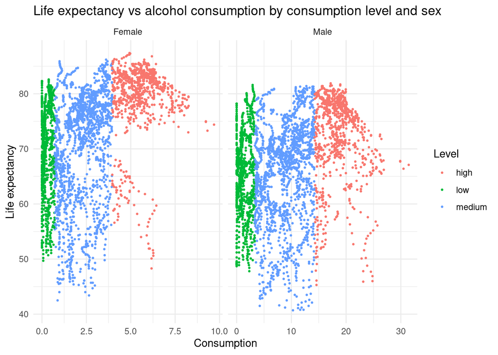

```r
df |>
  ggplot(aes(x = Consumption, y = Life_expectancy, color = Level)) +
  geom_point(size = .5) +
  facet_grid(cols = vars(Sex), scales="free") +
  labs(title = "Life expectancy vs alcohol consumption by consumption level and sex",
       y = "Life expectancy") +
  theme_minimal()
```

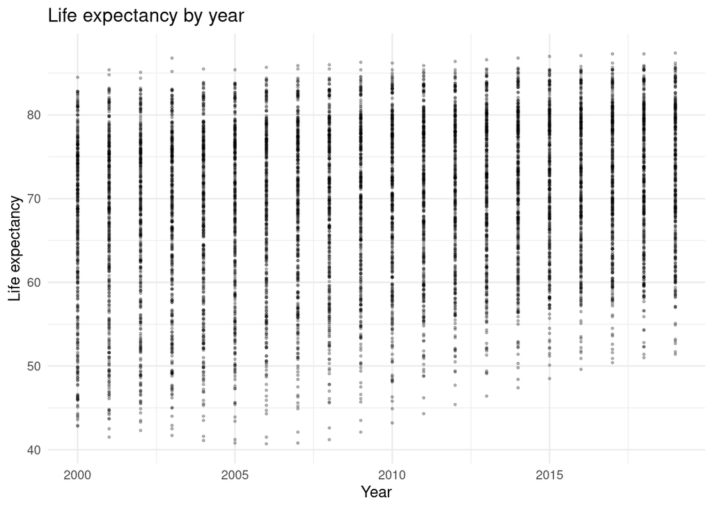

```r
df |>
  ggplot(aes(x = Year, y = Life_expectancy)) +
  geom_point(size = .5, alpha = .25) +
  labs(title = "Life expectancy by year",
       y = "Life expectancy") +
  theme_minimal()
```

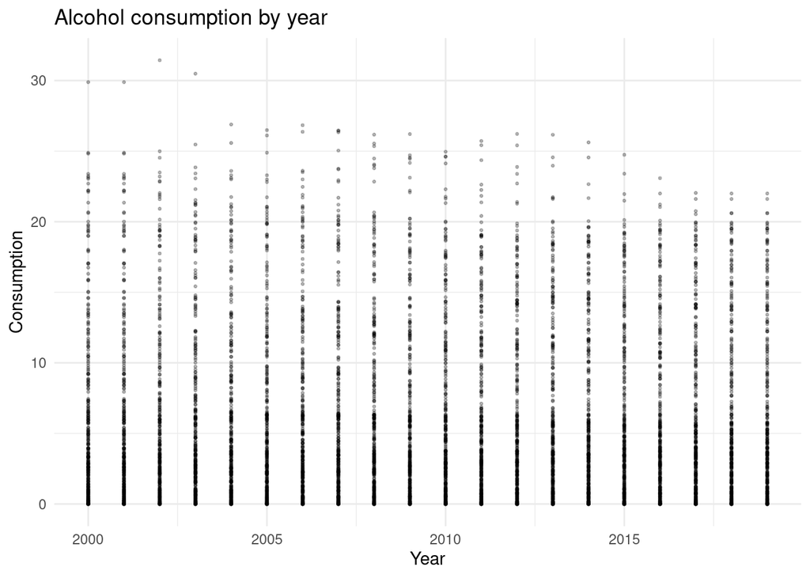

```r
df |>
  ggplot(aes(x = Year, y = Consumption)) +
  geom_point(size = .5, alpha = .25) +
  labs(title = "Alcohol consumption by year") +
  theme_minimal()
```

#### Summary

The merged dataset has `6692` observations and `9` variables of types character, int, and double. Of the numeric variables, from which I extracted summaries, none appears to contain any invalid or implausible values. There are `0` missing observations.

For the question “What is the association between life expectancy and alcohol consumption?”, I plotted a scatterplot of alcohol consumption vs life expectancy separated by sex and consumption level, which shows that the relationship between the variables (if any) is non-linear. While there are no obvious patterns in the low and medium consumption levels, there seems to be a downward trend in the relationship for the high consumption level, suggesting that life expectancy may decrease as consumption increases for this level.

For the question “Does this association differ by Sex?”, using the same scatterplot, I notice that the downward trend is less steep in women with high consumption levels compared to men in the same category. There does not seem to be any other differences in the association between the sexes.

Finally, for the question “How has life expectancy and alcohol consumption changed over time?”, I plotted scatterplots for both variables over time, which show that life expectancy has generally increased while alcohol consumption has largely stayed constant from 2000 to 2019.

### Visualization

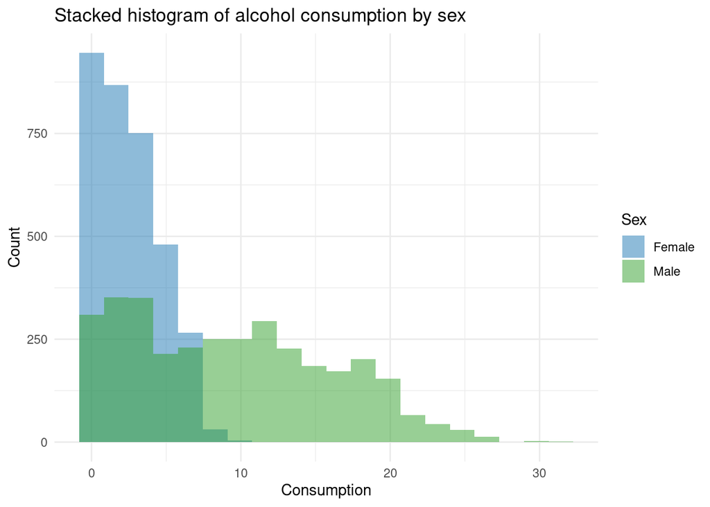

```r
df |>
  ggplot(aes(x = Consumption, fill = Sex)) +
  geom_histogram(position = "identity", bins = 20, alpha = 0.5) +
  scale_fill_manual(values = c("#1f78b4", "#33a02c"), name = "Sex") +
  labs(title = "Stacked histogram of alcohol consumption by sex",
       y = "Count") +
  theme_minimal()
```

The graph shows that females generally drink less than males. For the female group, most per capita consumption per year is near 0 liters, with the highest around 10 liters. For the male group, the distribution is much more spread out, with some per capita consumption reaching around 30 liters.

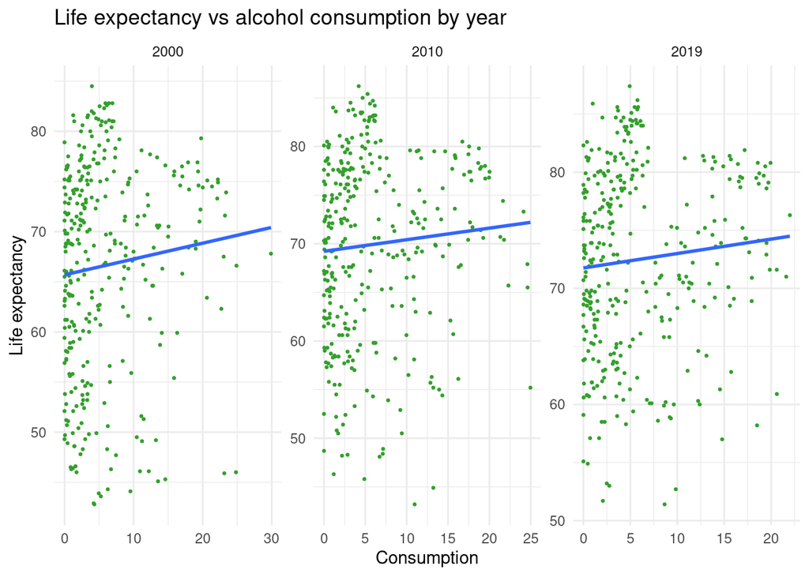

```r
df |>
  filter(Year %in% c(2000, 2010, 2019)) |>
  ggplot(aes(x = Consumption, y = Life_expectancy)) +
  geom_point(color = "#33a02c", size = 0.5) +
  geom_smooth(method = "lm", se = FALSE) +
  facet_wrap(~Year, nrow = 1, scales="free") +
  labs(title = "Life expectancy vs alcohol consumption by year",
       y = "Life expectancy") +
  theme_minimal()
```

The graph shows that consumption correlated more with life expectancy in 2000 compared to the other years. However, the patterns between the years are overall similar, and they show that life expectancy increases as consumption increases, which is a rather surprising pattern given the health risks associated with alcohol.

```r
ca_data <- df |> filter(Country == 'Canada')
ro_data <- df |> filter(Country == 'Romania')
summary(lm(Life_expectancy ~ Year + Sex, data = ca_data))
```

```
##
## Call:
## lm(formula = Life_expectancy ~ Year + Sex, data = ca_data)
##
## Residuals:
##      Min       1Q   Median       3Q      Max
## -0.53566 -0.17599  0.03276  0.18809  0.46039
##
## Coefficients:
##               Estimate Std. Error t value Pr(>|t|)
## (Intercept) -2.621e+02  1.472e+01  -17.81   <2e-16 ***
## Year         1.718e-01  7.326e-03   23.46   <2e-16 ***
## SexMale     -4.465e+00  8.449e-02  -52.85   <2e-16 ***
## ---
## Signif. codes:  0 '***' 0.001 '**' 0.01 '*' 0.05 '.' 0.1 ' ' 1
##
## Residual standard error: 0.2672 on 37 degrees of freedom
## Multiple R-squared:  0.9891, Adjusted R-squared:  0.9885
## F-statistic:  1672 on 2 and 37 DF,  p-value: < 2.2e-16
```

```r
summary(lm(Life_expectancy ~ Year + Sex, data = ro_data))
```

```
##
## Call:
## lm(formula = Life_expectancy ~ Year + Sex, data = ro_data)
##
## Residuals:
##      Min       1Q   Median       3Q      Max
## -1.98150 -0.36872  0.07673  0.58673  1.30286
##
## Coefficients:
##              Estimate Std. Error t value Pr(>|t|)
## (Intercept) -618.5833    45.0114  -13.74 4.14e-16 ***
## Year           0.3461     0.0224   15.45  < 2e-16 ***
## SexMale       -7.0800     0.2583  -27.41  < 2e-16 ***
## ---
## Signif. codes:  0 '***' 0.001 '**' 0.01 '*' 0.05 '.' 0.1 ' ' 1
##
## Residual standard error: 0.8169 on 37 degrees of freedom
## Multiple R-squared:  0.964,  Adjusted R-squared:  0.962
## F-statistic:   495 on 2 and 37 DF,  p-value: < 2.2e-16
```

I compared data for the countries Canada and Romania. The summaries show that for both females and males in Canada, an increase of 1 year over time correlates to an increase of 1.718e-01 years in the life expectancy, while for those in Romania, an increase of 1 year over time correlates to an increase of 0.3461 in the life expectancy. In Canada, males live 4.465 less years than females on average, while in Romania, males live 7.08 less years than females on average. Overall, the association between year and life expectancy and the difference in life expectancy between the sexes are more pronounced in Romania than Canada.

The models for Canada and Romania have adjusted R-squared values of 0.9885 and 0.962 respectively, while their p-values are both below 2.2e-16. While the former model has a slightly better fit, both models appear to be good fits, meaning we can be quite confident in the correlations.

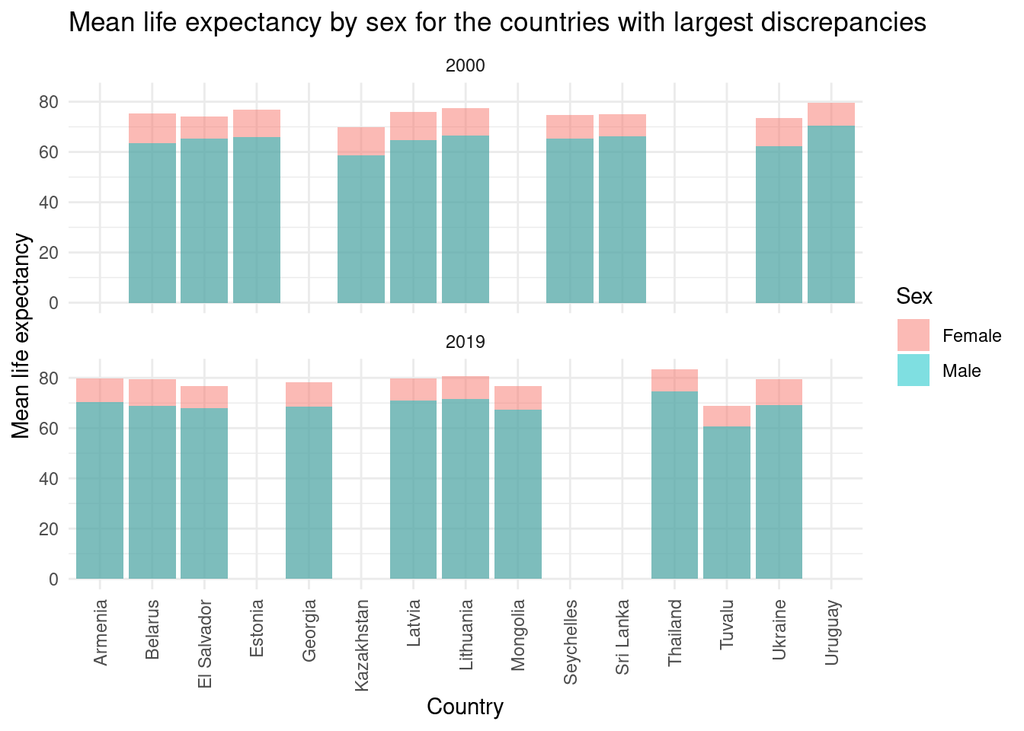

```r
df |>
  filter(Year == 2000 | Year == 2019) |>
  group_by(Country, Sex, Year) |>
  summarise(mean_life_expectancy = mean(Life_expectancy)) |>
  spread(key = Sex, value = mean_life_expectancy) |>
  ungroup() |>
  group_by(Year) |>
  slice_max(order_by = abs(Female - Male), n = 10) |>
  gather(key = Sex, value = mean_life_expectancy, Female:Male) |>
  ggplot(aes(x = Country, y = mean_life_expectancy, fill = Sex)) +
  geom_bar(stat = 'identity', position = 'identity', alpha = 0.5) +
  facet_wrap(~Year, ncol = 1) +
  labs(title = "Mean life expectancy by sex for the countries with largest discrepancies",
       y = "Mean life expectancy") +
  theme_minimal() +
  theme(axis.text.x = element_text(angle = 90, vjust = 0.5, hjust=1))
```

Between both plots, there appears to be differences between the top ten countries by discrepancy in 2019 compared to 2000. For instance, Urugray disappeared and Armenia appeared in 2019. We can also see that the mean life expectancies for the countries are generally closer to 80 years in 2019 compared to 2000, which confirms an earlier observation made in the previous EDA section. As for the discrepancies themselves, they seem to be consistent across all the shown countries and years. This makes sense since increases in longevity should be similar for both sexes when considering external factors such as general availability of medicine.

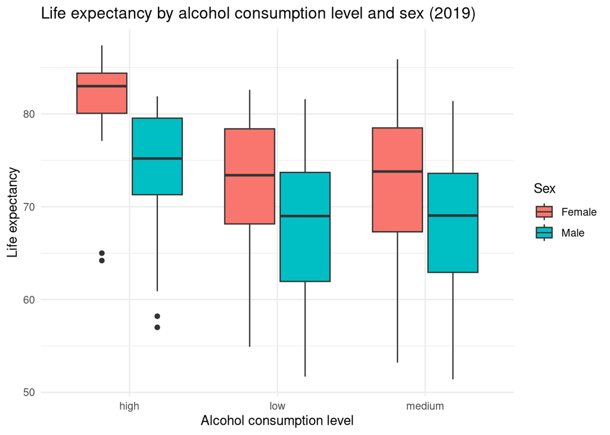

```r
df |>
  filter(Year == 2019) |>
  ggplot(aes(x = Level, y = Life_expectancy, fill = Sex)) +
  geom_boxplot() +
  labs(title = "Life expectancy by alcohol consumption level and sex (2019)",
       x = "Alcohol consumption level",
       y = "Life expectancy") +
  theme_minimal()
```

For all three levels, females have longer life expectancies. Consistent with the scatterplots from earlier, this boxplot shows that life expectancy generally increases with consumption level, which as mentioned above is a surprising conclusion. This is most apparent in the high consumption level, where the life expectancies of both males and females are significantly higher than those of the lower levels.

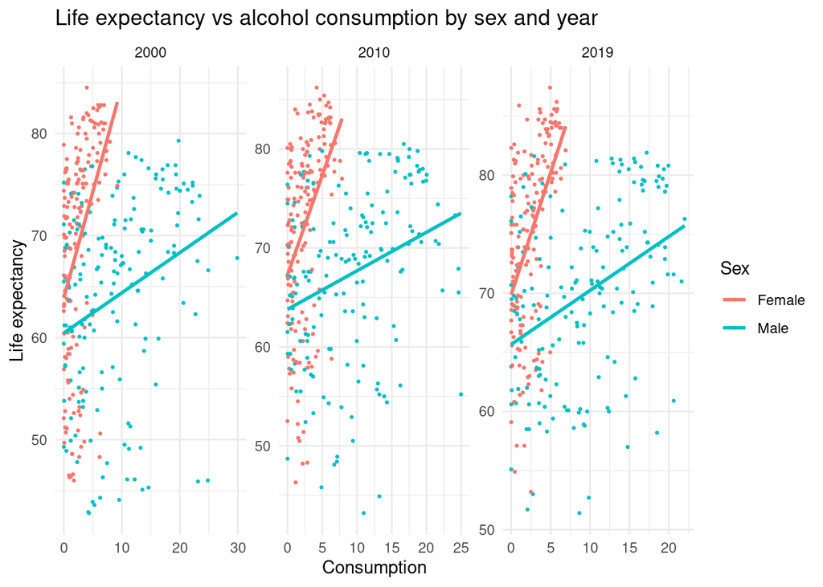

```r
df |>
  filter(Year %in% c(2000, 2010, 2019)) |>
  ggplot(aes(x = Consumption, y = Life_expectancy)) +
  geom_point(aes(color = Sex), size = 0.5) +
  geom_smooth(aes(color = Sex), method = "lm", se = FALSE) +
  facet_wrap(~Year, nrow = 1, scales="free") +
  labs(title = "Life expectancy vs alcohol consumption by sex and year",
       y = "Life expectancy") +
  theme_minimal()
```

The visualization I chose is a modification of the scatterplots from earlier, except now it accounts for sex. The plot shows that for all three years, life expectancy increases with consumption for both sexes, and this increase is greater for females than males. Thus, life expectancy is positively correlated with consumption for both sexes, and this trend is consistent over time (from 2000 to 2019).

### Advanced Regression

```r
summary(lm(Life_expectancy ~ Level + scale(Population) + Year + Sex, data = df))
```

```
##
## Call:
## lm(formula = Life_expectancy ~ Level + scale(Population) + Year +
##     Sex, data = df)
##
## Residuals:
##     Min      1Q  Median      3Q     Max
## -26.903  -5.282   1.827   5.761  16.837
##
## Coefficients:
##                     Estimate Std. Error t value Pr(>|t|)
## (Intercept)       -547.11265   35.25614 -15.518  < 2e-16 ***
## Levellow            -8.23057    0.28552 -28.827  < 2e-16 ***
## Levelmedium         -7.88309    0.24857 -31.714  < 2e-16 ***
## scale(Population)    0.38438    0.10143   3.789 0.000152 ***
## Year                 0.31119    0.01754  17.740  < 2e-16 ***
## SexMale             -5.06841    0.20204 -25.086  < 2e-16 ***
## ---
## Signif. codes:  0 '***' 0.001 '**' 0.01 '*' 0.05 '.' 0.1 ' ' 1
##
## Residual standard error: 8.264 on 6686 degrees of freedom
## Multiple R-squared:  0.2428, Adjusted R-squared:  0.2422
## F-statistic: 428.7 on 5 and 6686 DF,  p-value: < 2.2e-16
```

```r
spline_fit <- gam(Life_expectancy ~ Level + s(scale(Population), bs = "cr", k = 4) + Year + Sex, data = df)
summary(spline_fit)
```

```
##
## Family: gaussian
## Link function: identity
##
## Formula:
## Life_expectancy ~ Level + s(scale(Population), bs = "cr", k = 4) +
##     Year + Sex
##
## Parametric coefficients:
##               Estimate Std. Error t value Pr(>|t|)
## (Intercept) -555.83935   35.05353  -15.86   <2e-16 ***
## Levellow      -8.25867    0.28579  -28.90   <2e-16 ***
## Levelmedium   -8.21650    0.24959  -32.92   <2e-16 ***
## Year           0.31562    0.01744   18.10   <2e-16 ***
## SexMale       -5.06834    0.20076  -25.25   <2e-16 ***
## ---
## Signif. codes:  0 '***' 0.001 '**' 0.01 '*' 0.05 '.' 0.1 ' ' 1
##
## Approximate significance of smooth terms:
##                        edf Ref.df    F p-value
## s(scale(Population)) 2.988      3 33.7  <2e-16 ***
## ---
## Signif. codes:  0 '***' 0.001 '**' 0.01 '*' 0.05 '.' 0.1 ' ' 1
##
## R-sq.(adj) =  0.252   Deviance explained = 25.3%
## GCV = 67.509  Scale est. = 67.428    n = 6692
```

The adjusted R-squared of the linear model (0.2422) is less than that of the spline model (0.252). However, they are quite similar, meaning both models are poor to moderate fits of the data, though all predictors in both models are significant (< 0.001).

Overall, life expectancy increases with year and scaled population, with differences between consumption levels and sex.

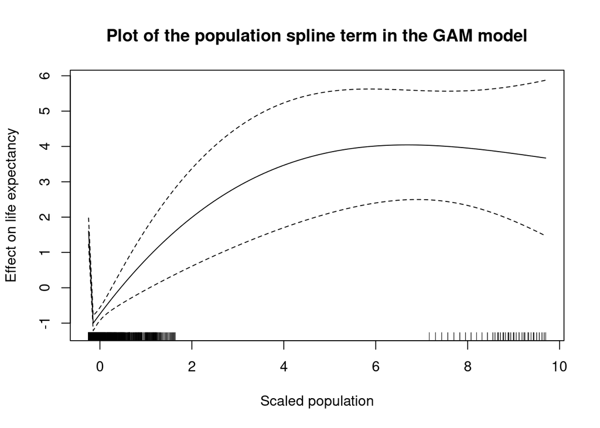

```r
plot(spline_fit,
     main = "Plot of the population spline term in the GAM model",
     xlab = "Scaled population",
     ylab = "Effect on life expectancy")
```

The plot shows that as scaled population increases, life expectancy generally increases, with the exception of observations with scaled population below 0 and above 7. Note however that there are no observations with scaled populations between 2 and 7, meaning that the few observations with scaled populations above 7 are likely to be influential points when fitting the spline.

```r
df2 <- df |>
  group_by(Country, Sex) |>
  mutate(mean_consumption = mean(Consumption),
         mean_life_expectancy = mean(Life_expectancy))

summary(lm(mean_life_expectancy ~ mean_consumption + scale(Population) + Sex, data = df2))
```

```
##
## Call:
## lm(formula = mean_life_expectancy ~ mean_consumption + scale(Population) +
##     Sex, data = df2)
##
## Residuals:
##     Min      1Q  Median      3Q     Max
## -22.717  -5.402   2.098   6.203  15.455
##
## Coefficients:
##                   Estimate Std. Error t value Pr(>|t|)
## (Intercept)       70.77043    0.15503 456.502   <2e-16 ***
## mean_consumption   0.57431    0.02126  27.011   <2e-16 ***
## scale(Population)  0.25778    0.10280   2.508   0.0122 *
## SexMale           -8.95647    0.25088 -35.700   <2e-16 ***
## ---
## Signif. codes:  0 '***' 0.001 '**' 0.01 '*' 0.05 '.' 0.1 ' ' 1
##
## Residual standard error: 8.399 on 6688 degrees of freedom
## Multiple R-squared:  0.1668, Adjusted R-squared:  0.1664
## F-statistic: 446.4 on 3 and 6688 DF,  p-value: < 2.2e-16
```

```r
summary(gam(mean_life_expectancy ~ mean_consumption + s(Population, bs = "cr", k = 4) + Sex, data = df2))
```

```
##
## Family: gaussian
## Link function: identity
##
## Formula:
## mean_life_expectancy ~ mean_consumption + s(Population, bs = "cr",
##     k = 4) + Sex
##
## Parametric coefficients:
##                  Estimate Std. Error t value Pr(>|t|)
## (Intercept)      70.77305    0.15475  457.33   <2e-16 ***
## mean_consumption  0.57329    0.02127   26.95   <2e-16 ***
## SexMale          -8.94952    0.25056  -35.72   <2e-16 ***
## ---
## Signif. codes:  0 '***' 0.001 '**' 0.01 '*' 0.05 '.' 0.1 ' ' 1
##
## Approximate significance of smooth terms:
##                 edf Ref.df     F  p-value
## s(Population) 2.965  2.999 11.47 2.26e-07 ***
## ---
## Signif. codes:  0 '***' 0.001 '**' 0.01 '*' 0.05 '.' 0.1 ' ' 1
##
## R-sq.(adj) =   0.17   Deviance explained = 17.1%
## GCV =  70.32  Scale est. = 70.258    n = 6692
```

The adjusted R-squared of the linear model (0.1664) is less than that of the spline model (0.17). However, they are quite similar, meaning both models are poor to moderate fits of the data, though all predictors in both models are significant (< 0.001, < 0.05 for scaled population).

From the linear model, an increase of 1 liter in the mean consumption correlates with an increase of 0.57431 in life expectancy. The life expectancy of males is 8.95647 years less than that of females. An increase of 1 unit of scaled population correlates with an increase of 0.25778 years.

From the spline model, an increase of 1 liter in the mean consumption correlates with an increase of 0.57329 in life expectancy. The life expectancy of males is 8.94952 years less than that of females. Finally, the population spline term is noticeably non-linear with an edf of 2.965.

Overall, life expectancy increases with mean consumption per country and scaled population, with differences between consumption levels and sex.

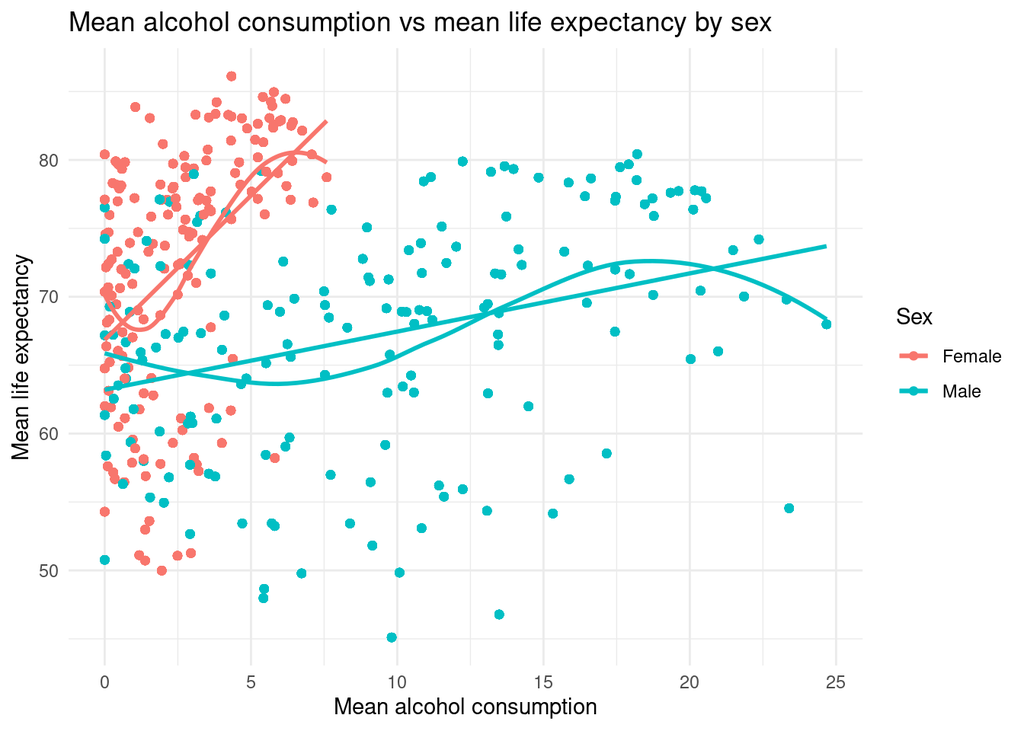

```r
df2 |>
  ggplot(aes(x = mean_consumption, y = mean_life_expectancy, color = Sex)) +
  geom_point() +
  geom_smooth(method = "lm", fill = NA) +
  geom_smooth(method = "loess", se = FALSE) +
  labs(title = "Mean alcohol consumption vs mean life expectancy by sex",
       x = "Mean alcohol consumption",
       y = "Mean life expectancy") +
  theme_minimal()
```